# konicek_homework_13

Kelli

2025-04-25

## Libraries

```r
library(arm)
library(car)
library(here)
library(tidyverse)
library(ggeffects)
library(MuMIn)
library(GGally)
library(glmmTMB)
```

```r
library(gridExtra)
library(lme4)
library(lmerTest)
library(sjPlot)
#install.packages("RVAideMemoire")
library(RVAideMemoire)
library(DHARMa)
```

## Data

```r
ohia_raw <- read_csv(here("week_13", "data", "ohia_merged.csv"))
```

Barton et al. (2020) investigated local adaptation in drought tolerance across a broad rainfall gradient on Oahu.

We will focus on data from the greenhouse experiment.

Seedlings were planted in germination trays and watered normally for four weeks. After four weeks seedlings were placed into one of two treatments: a control treatment with normal daily watering, or a ‘press drought’ treatment in which seedlings were watered every other day, to 80% capacity.

After six weeks of the press drought half of the seedlings (randomly chosen at the start of the experiment) were harvested for phenotypic measurements (if they survived), while the remaining seedlings (from both treatments) were placed into terminal drought (no more watering). The attached file contains data on each seedling in the experiment. The column definitions are as follows:

ID Seedling experimental identification number.

BLOCK Experimental block, due to variation in germination timing. POPULATION Source of seeds, collected on Oahu Island.

DROUGHT Experimental water treatment: control (watered every other day to 100% field capacity) and drought (watered every other day to 80% field capacity).

FATE Harvested after press drought treatment, or subjected to terminal drought with no water until the seedling died.

DEAD Binary mortality (1 = dead; 0 = alive).

HEIGHT Seedling height at harvest (cm). SHOOT Dry shoot biomass at harvest (g). ROOT Dry root biomass at harvest (g).

LONGEVITY Number of days in terminal drought with no water before dying.

TERMINAL_GWC Soil gravimetric water content (% field capacity) at the time of mortality in terminal drought.

MAR Historical mean annual rainfall at the site from which the seeds were collected (cm)

MET Historical mean annual evapotranspiration at the site from which the seeds were collected (mm)

# 1.

## Height

*Using the seedlings that were harvested after the press drought treatment, analyze how seedling height varies among treatments and populations.*

Take a peek at the spread of the data:

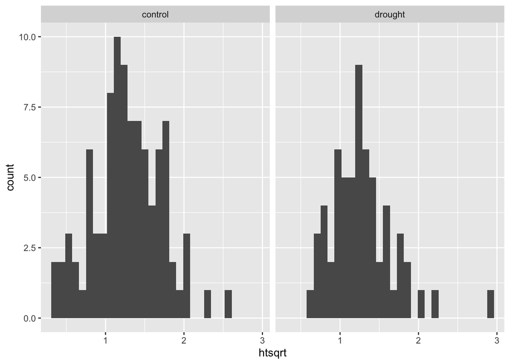

```r
ohia_h<- ohia_raw %>%
  mutate(htsqrt = sqrt(Height))

ohia_h$Drought<-as.factor(ohia_h$Drought)

height <- ggplot(ohia_h, aes(x=htsqrt))+
  geom_histogram()+
  facet_wrap(~Drought)
height
```

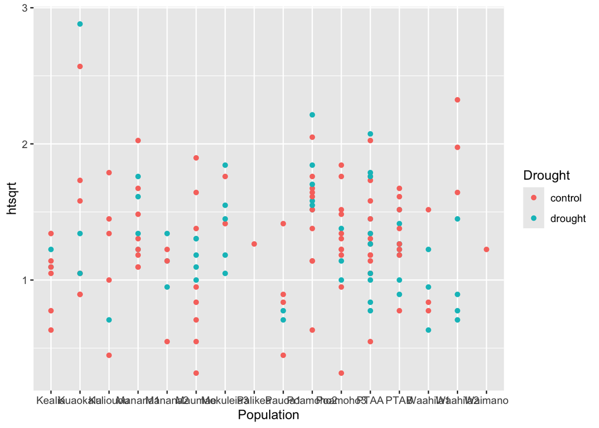

```r
vary <- ggplot(ohia_h,aes(x=Population, y= htsqrt, color=Drought))+geom_point()
vary
```

So we want to use a glmm for this set because we will have nested variables and the response distribution is pretty normal. Also, maybe I should remove Palikea and Waimano, I dunno I guess not since I use them for mortality stuff.

*set up models to test:*

*whether populations differ in height*

```r
ohia.h.pop = lmer(htsqrt ~ Population+(1|Block), data=ohia_h)
summary(ohia.h.pop)
```

```
## Linear mixed model fit by REML. t-tests use Satterthwaite's method [
## lmerModLmerTest]
## Formula: htsqrt ~ Population + (1 | Block)
##    Data: ohia_h
##
## REML criterion at convergence: 166.5
##
## Scaled residuals:
##     Min      1Q  Median      3Q     Max
## -2.2165 -0.5788 -0.0231  0.5948  3.3939
##
## Random effects:
##  Groups   Name        Variance Std.Dev.
##  Block    (Intercept) 0.02772  0.1665
##  Residual             0.15085  0.3884
## Number of obs: 155, groups:  Block, 9
##
## Fixed effects:
##                      Estimate Std. Error        df t value Pr(>|t|)
## (Intercept)           1.04671    0.20804   5.90607   5.031  0.00249 **
## PopulationKuaokala    0.44392    0.26384   7.39769   1.683  0.13404
## PopulationKuliouou    0.07561    0.31008   5.65755   0.244  0.81594
## PopulationManana1     0.46928    0.26372   7.82874   1.779  0.11387
## PopulationManana2    -0.06169    0.28999  10.06487  -0.213  0.83579
## PopulationMaumae      0.09657    0.25783   7.50038   0.375  0.71836
## PopulationMokuleia3   0.34529    0.28373   9.24948   1.217  0.25377
## PopulationPalikea     0.24824    0.45840  55.57353   0.542  0.59030
## PopulationPauoa1     -0.19388    0.21242 138.86660  -0.913  0.36297
## PopulationPoamoho2    0.43102    0.24962   6.99767   1.727  0.12788
## PopulationPoamoho3    0.22775    0.25225   7.11792   0.903  0.39612
## PopulationPTAA        0.28440    0.15777 136.08157   1.803  0.07366 .
## PopulationPTAB        0.22718    0.28263   3.91590   0.804  0.46747
## PopulationWaahila1   -0.20689    0.28095  12.01613  -0.736  0.47561
## PopulationWaahila2    0.16361    0.28256   9.87088   0.579  0.57553
## PopulationWaimano     0.17803    0.47102  27.33935   0.378  0.70837
## ---
## Signif. codes:  0 '***' 0.001 '**' 0.01 '*' 0.05 '.' 0.1 ' ' 1
```

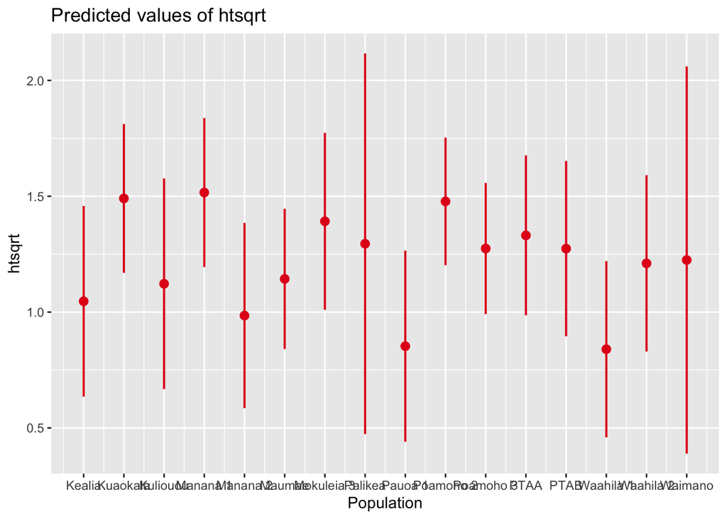

```r
plot_model(ohia.h.pop, type = "eff", terms="Population")
```

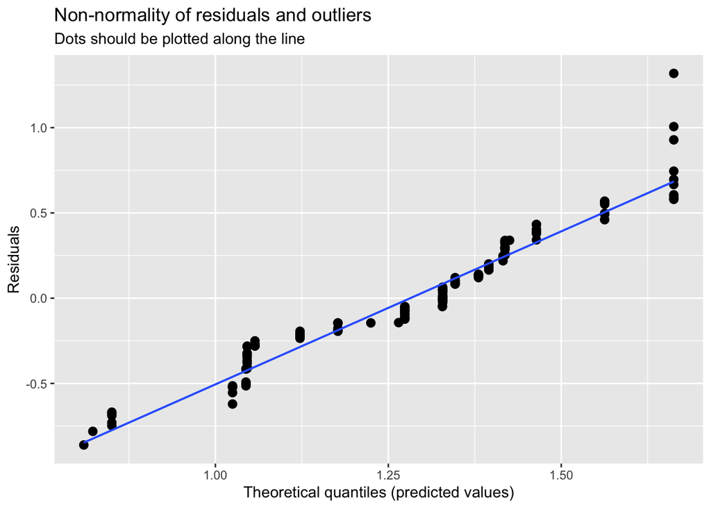

```
##
## [[2]]
## [[2]]$Block
```

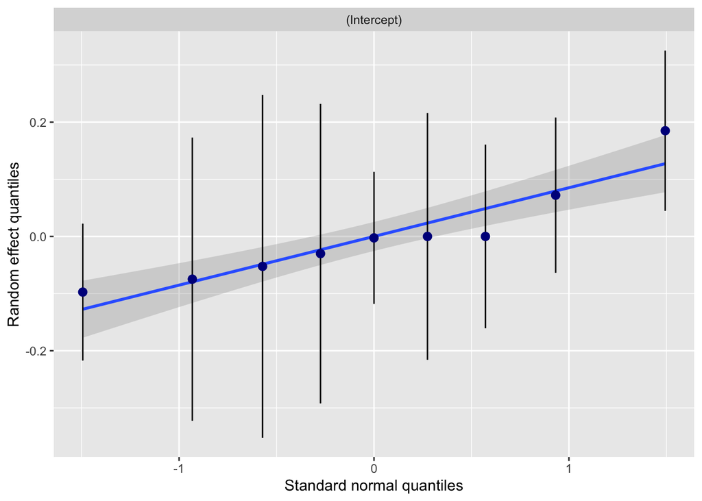

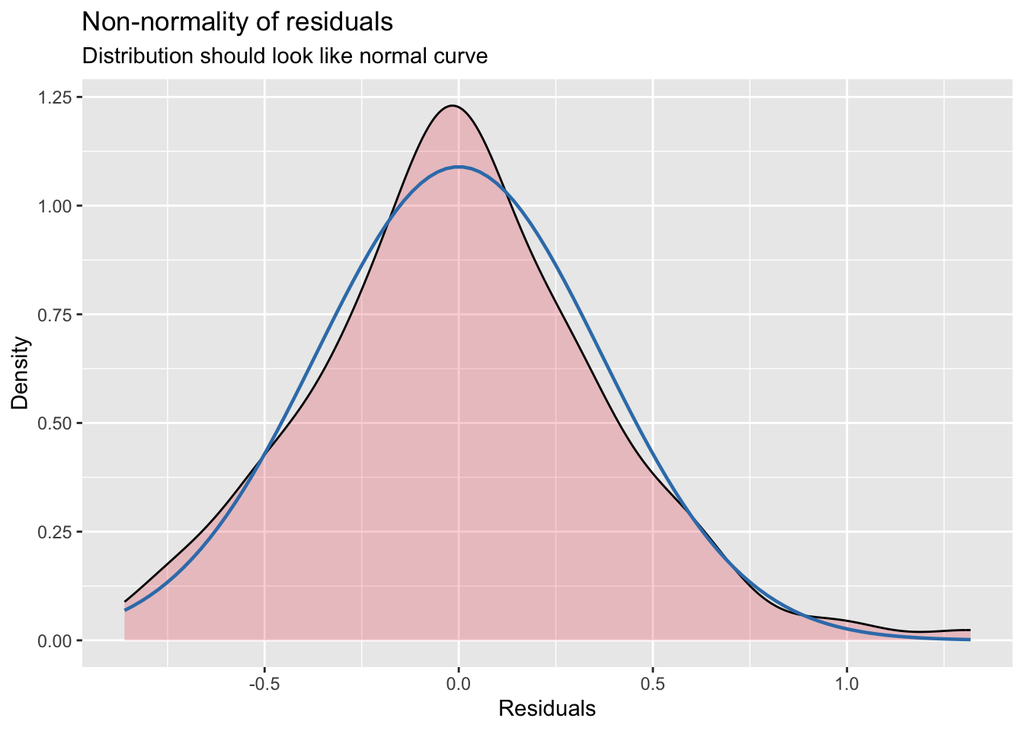

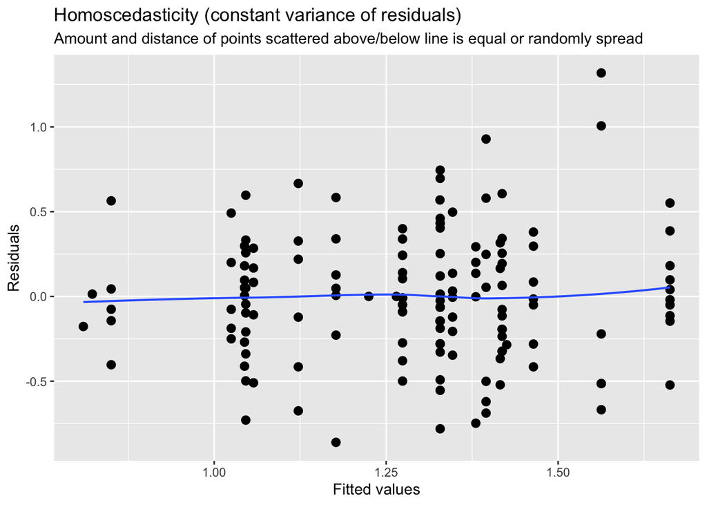

```r
plot_model(ohia.h.pop, type = "diag")
```

No, it does not look like populations differ in height.

*whether the press drought treatment affects height*

```r
ohia.h.dr = lmer(htsqrt ~ Drought+(1|Block/Population), data=ohia_h)
summary(ohia.h.dr)
```

```
## Linear mixed model fit by REML. t-tests use Satterthwaite's method [
## lmerModLmerTest]
## Formula: htsqrt ~ Drought + (1 | Block/Population)
##    Data: ohia_h
##
## REML criterion at convergence: 171.7
##
## Scaled residuals:
##     Min      1Q  Median      3Q     Max
## -2.3021 -0.6687 -0.0358  0.5905  3.6619
##
## Random effects:
##  Groups           Name        Variance Std.Dev.
##  Population:Block (Intercept) 0.026764 0.16360
##  Block            (Intercept) 0.002615 0.05114
##  Residual                     0.153211 0.39142
## Number of obs: 155, groups:  Population:Block, 23; Block, 9
##
## Fixed effects:
##                 Estimate Std. Error        df t value Pr(>|t|)
## (Intercept)      1.26924    0.05946   8.37302  21.345 1.35e-08 ***
## Droughtdrought  -0.02207    0.06647 146.25199  -0.332     0.74
## ---
## Signif. codes:  0 '***' 0.001 '**' 0.01 '*' 0.05 '.' 0.1 ' ' 1
##
## Correlation of Fixed Effects:
##             (Intr)
## Droghtdrght -0.415
```

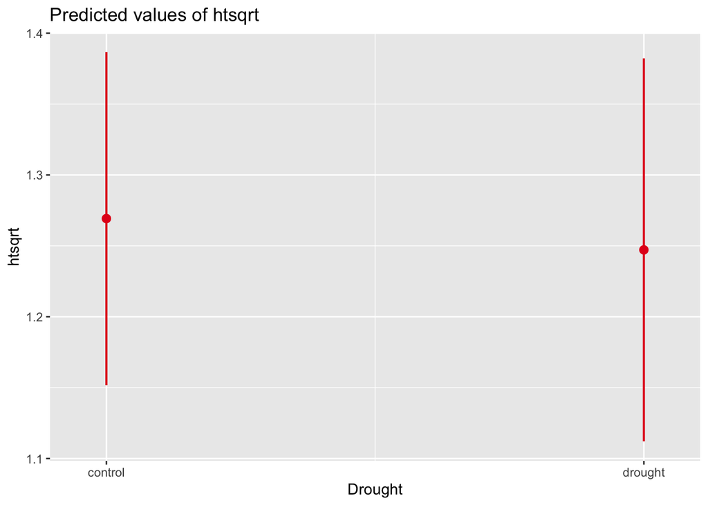

```r
plot_model(ohia.h.dr, type = "eff", terms=c("Drought"))
```

It looks like the drought treatments didnʻt affect height.

*whether populations differ in how press drought affects height.*

OK. I am confused because you mentioned that we should be using fixed:random interactions, but I am having a hard time deciding which wording is implying that would be appropriate.

```r
ohia.h.int= lmer(htsqrt ~ Drought*Population + (1|Block), data=ohia_h) #Okay this means WHICH POPULATIONS DIFFER?

ohia.h.rnd= lmer(htsqrt ~ Drought + (Drought|Population) + (1|Block), data=ohia_h) #This means DO populations differ AT ALL in their response to drought?
summary(ohia.h.int)
```

```
## Linear mixed model fit by REML. t-tests use Satterthwaite's method [
## lmerModLmerTest]
## Formula: htsqrt ~ Drought * Population + (1 | Block)
##    Data: ohia_h
##
## REML criterion at convergence: 158.4
##
## Scaled residuals:
##      Min       1Q   Median       3Q      Max
## -2.35305 -0.55851 -0.03803  0.50686  2.95309
##
## Random effects:
##  Groups   Name        Variance Std.Dev.
##  Block    (Intercept) 0.02744  0.1656
##  Residual             0.14483  0.3806
## Number of obs: 155, groups:  Block, 9
##
## Fixed effects:
##                                     Estimate Std. Error        df t value
## (Intercept)                          1.00000    0.22024   7.92149   4.541
## Droughtdrought                       0.15457    0.31073 122.69656   0.497
## PopulationKuaokala                   0.38115    0.28536   9.87930   1.336
## PopulationKuliouou                   0.20537    0.32390   7.32354   0.634
## PopulationManana1                    0.51810    0.28418  10.82997   1.823
## PopulationManana2                   -0.10121    0.33725  17.62499  -0.300
## PopulationMaumae                     0.13006    0.28101  10.75633   0.463
## PopulationMokuleia3                  0.51535    0.37131  24.75897   1.388
## PopulationPalikea                    0.30248    0.45818  53.61096   0.660
## PopulationPauoa1                    -0.09662    0.25081 122.85123  -0.385
## PopulationPoamoho2                   0.40084    0.26896   9.90512   1.490
## PopulationPoamoho3                   0.34429    0.26729   9.50208   1.288
## PopulationPTAA                       0.32378    0.18569 122.69656   1.744
## PopulationPTAB                       0.32853    0.30667   5.91407   1.071
## PopulationWaahila1                  -0.12034    0.33458  19.24585  -0.360
## PopulationWaahila2                   0.81765    0.33458  19.24585   2.444
## PopulationWaimano                    0.22475    0.46986  28.67251   0.478
## Droughtdrought:PopulationKuaokala    0.14932    0.41886 122.16533   0.356
## Droughtdrought:PopulationKuliouou   -0.65284    0.51995 122.69656  -1.256
## Droughtdrought:PopulationManana1    -0.05521    0.38841 122.69656  -0.142
## Droughtdrought:PopulationManana2     0.01804    0.43943 122.69656   0.041
```

[output cut: 27 more lines]

```
## Droughtdrought:PopulationKuaokala   0.72208
## Droughtdrought:PopulationKuliouou   0.21165
## Droughtdrought:PopulationManana1    0.88721
## Droughtdrought:PopulationManana2    0.96731
## Droughtdrought:PopulationMaumae     0.92892
## Droughtdrought:PopulationMokuleia3  0.46351
## Droughtdrought:PopulationPauoa1     0.48036
## Droughtdrought:PopulationPoamoho2   0.75585
## Droughtdrought:PopulationPoamoho3   0.33250
## Droughtdrought:PopulationPTAA       0.65283
## Droughtdrought:PopulationPTAB       0.47726
## Droughtdrought:PopulationWaahila1   0.66104
## Droughtdrought:PopulationWaahila2   0.00647 **
## ---
## Signif. codes:  0 '***' 0.001 '**' 0.01 '*' 0.05 '.' 0.1 ' ' 1
```

```
## fit warnings:
## fixed-effect model matrix is rank deficient so dropping 2 columns / coefficients
```

```r
summary(ohia.h.rnd)
```

```
## Linear mixed model fit by REML. t-tests use Satterthwaite's method [
## lmerModLmerTest]
## Formula: htsqrt ~ Drought + (Drought | Population) + (1 | Block)
##    Data: ohia_h
##
## REML criterion at convergence: 170
##
## Scaled residuals:
##     Min      1Q  Median      3Q     Max
## -2.2758 -0.6054 -0.0328  0.5522  3.5240
##
## Random effects:
##  Groups     Name           Variance Std.Dev. Corr
##  Population (Intercept)    0.01539  0.1240
##             Droughtdrought 0.01016  0.1008   1.00
##  Block      (Intercept)    0.01139  0.1067
##  Residual                  0.14977  0.3870
## Number of obs: 155, groups:  Population, 16; Block, 9
##
## Fixed effects:
##                Estimate Std. Error       df t value Pr(>|t|)
## (Intercept)     1.25939    0.06653  8.28863  18.929 4.11e-08 ***
## Droughtdrought -0.03912    0.07220 21.90729  -0.542    0.593
## ---
## Signif. codes:  0 '***' 0.001 '**' 0.01 '*' 0.05 '.' 0.1 ' ' 1
##
## Correlation of Fixed Effects:
##             (Intr)
## Droghtdrght -0.143
## optimizer (nloptwrap) convergence code: 0 (OK)
## boundary (singular) fit: see help('isSingular')
```

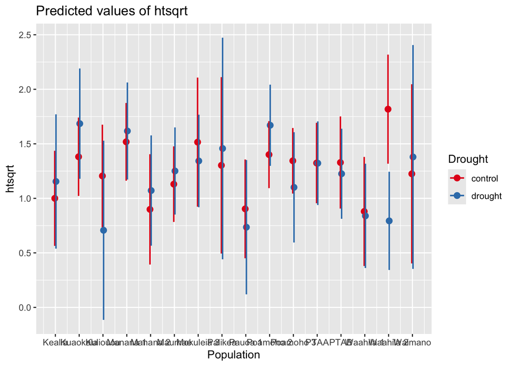

```r
plot_model(ohia.h.int, type = "pred", terms=c("Population","Drought"))
```

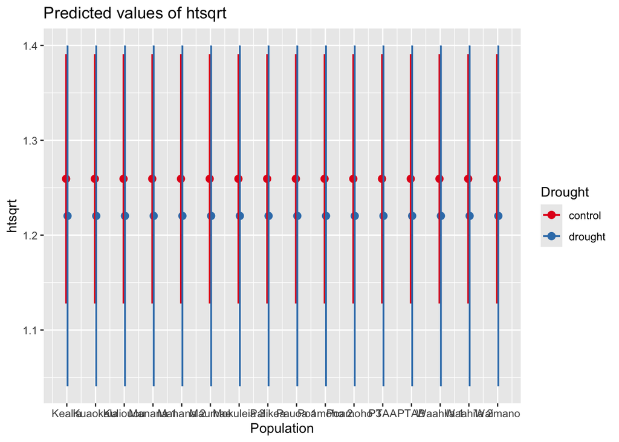

```r
plot_model(ohia.h.rnd, type = "pred", terms=c("Population","Drought"))
```

### height vs. MAR raw data:

*Next, set up models to test whether historical rainfall at a site predicts the height of seedlings*

```r
ohia.mar= lmer(htsqrt ~ MAR + (1|Population) + (1|Block), data=ohia_h)
summary(ohia.mar)
```

```
## Linear mixed model fit by REML. t-tests use Satterthwaite's method [
## lmerModLmerTest]
## Formula: htsqrt ~ MAR + (1 | Population) + (1 | Block)
##    Data: ohia_h
##
## REML criterion at convergence: 180.7
##
## Scaled residuals:
##     Min      1Q  Median      3Q     Max
## -2.2257 -0.6402 -0.0359  0.5533  3.5980
##
## Random effects:
##  Groups     Name        Variance Std.Dev.
##  Population (Intercept) 0.02791  0.1671
##  Block      (Intercept) 0.01543  0.1242
##  Residual               0.15010  0.3874
## Number of obs: 155, groups:  Population, 16; Block, 9
##
## Fixed effects:
##               Estimate Std. Error         df t value Pr(>|t|)
## (Intercept)  1.3265402  0.1273481 10.7946654  10.417 5.76e-07 ***
## MAR         -0.0003813  0.0004632 11.3460042  -0.823    0.427
## ---
## Signif. codes:  0 '***' 0.001 '**' 0.01 '*' 0.05 '.' 0.1 ' ' 1
##
## Correlation of Fixed Effects:
##     (Intr)
## MAR -0.820
```

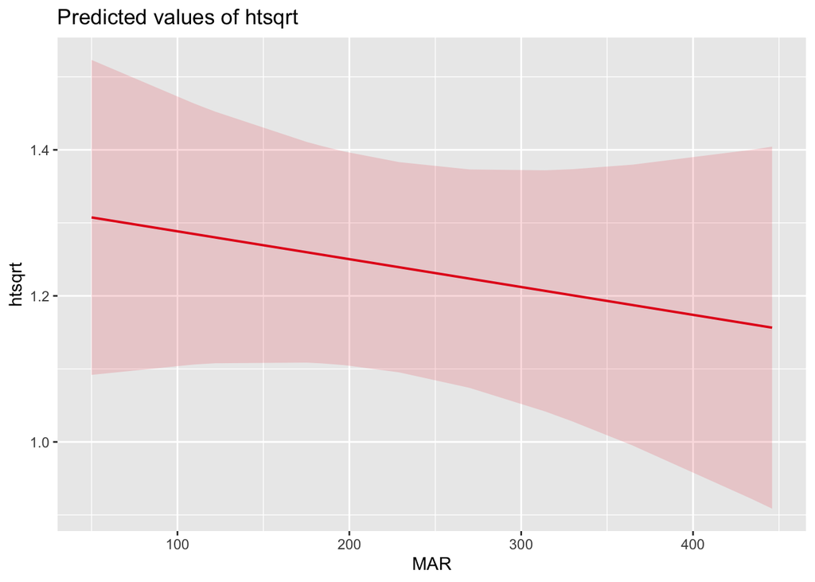

```r
plot_model(ohia.mar, type = "eff", terms=c("MAR"))
```

I… I guess not.

*and whether historical rainfall at a site predicts the effect of press drought on height.*

```r
ohia.mar.dr= lmer(htsqrt ~ MAR*Drought +(1|Population)+ (1|Block), data=ohia_h)
summary(ohia.mar.dr)
```

```
## Linear mixed model fit by REML. t-tests use Satterthwaite's method [
## lmerModLmerTest]
## Formula: htsqrt ~ MAR * Drought + (1 | Population) + (1 | Block)
##    Data: ohia_h
##
## REML criterion at convergence: 197.6
##
## Scaled residuals:
##     Min      1Q  Median      3Q     Max
## -2.2366 -0.6278 -0.0204  0.5749  3.5867
##
## Random effects:
##  Groups     Name        Variance Std.Dev.
##  Population (Intercept) 0.02771  0.1665
##  Block      (Intercept) 0.01659  0.1288
##  Residual               0.15181  0.3896
## Number of obs: 155, groups:  Population, 16; Block, 9
##
## Fixed effects:
##                      Estimate Std. Error         df t value Pr(>|t|)
## (Intercept)         1.327e+00  1.362e-01  1.404e+01   9.744 1.26e-07 ***
## MAR                -3.451e-04  4.965e-04  1.458e+01  -0.695    0.498
## Droughtdrought      4.890e-03  1.179e-01  1.414e+02   0.041    0.967
## MAR:Droughtdrought -1.393e-04  4.610e-04  1.422e+02  -0.302    0.763
## ---
## Signif. codes:  0 '***' 0.001 '**' 0.01 '*' 0.05 '.' 0.1 ' ' 1
##
## Correlation of Fixed Effects:
##             (Intr) MAR    Drghtd
## MAR         -0.821
## Droghtdrght -0.337  0.302
## MAR:Drghtdr  0.274 -0.349 -0.826
```

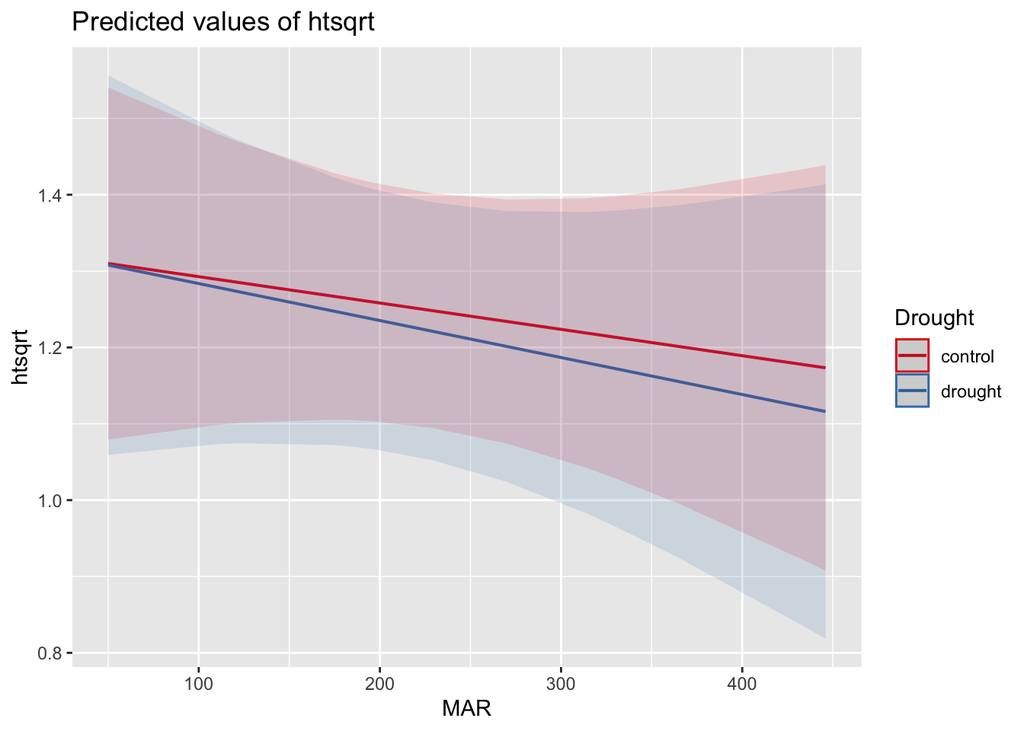

```r
plot_model(ohia.mar.dr, type = "pred", terms=c("MAR","Drought"))
```

WELL…. I guess no.

### Height and MET

*set up models to test:*

*whether historical evapotranspiration at a site predicts the height of seedlings*

```r
ohia.met= lmer(htsqrt ~ MET + (1|Population) + (1|Block), data=ohia_h)
summary(ohia.met)
```

```
## Linear mixed model fit by REML. t-tests use Satterthwaite's method [
## lmerModLmerTest]
## Formula: htsqrt ~ MET + (1 | Population) + (1 | Block)
##    Data: ohia_h
##
## REML criterion at convergence: 181.7
##
## Scaled residuals:
##     Min      1Q  Median      3Q     Max
## -2.3048 -0.6424 -0.0477  0.5517  3.6584
##
## Random effects:
##  Groups     Name        Variance Std.Dev.
##  Population (Intercept) 0.02438  0.1561
##  Block      (Intercept) 0.01027  0.1013
##  Residual               0.15158  0.3893
## Number of obs: 155, groups:  Population, 16; Block, 9
##
## Fixed effects:
##               Estimate Std. Error         df t value Pr(>|t|)
## (Intercept)  1.4377330  0.1860845  8.9228969   7.726 3.07e-05 ***
## MET         -0.0002205  0.0002003  9.4394581  -1.101    0.298
## ---
## Signif. codes:  0 '***' 0.001 '**' 0.01 '*' 0.05 '.' 0.1 ' ' 1
##
## Correlation of Fixed Effects:
##     (Intr)
## MET -0.935
```

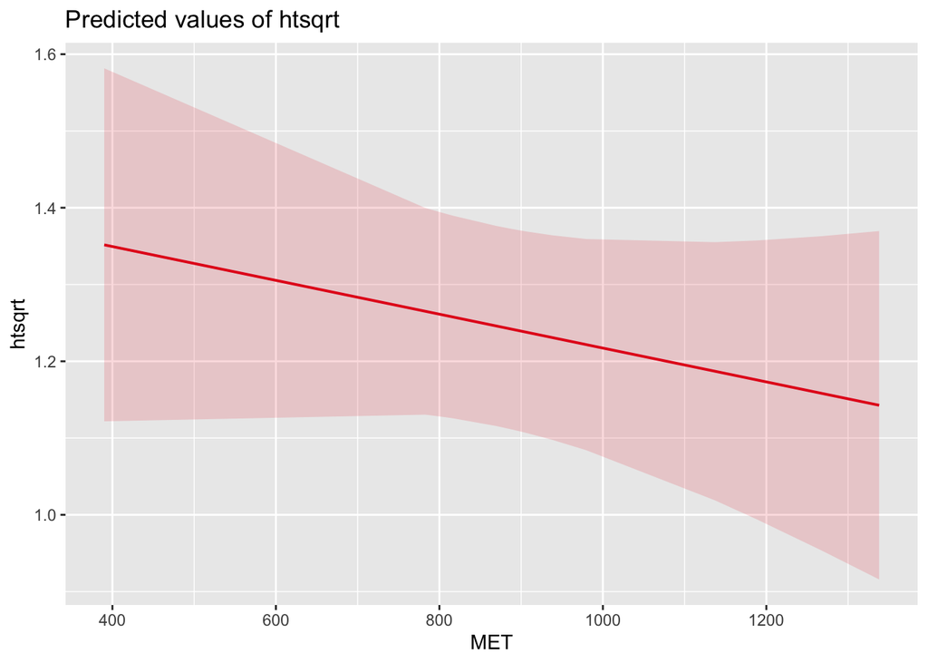

```r
plot_model(ohia.met, type = "pred", terms=c("MET"))
```

NNNNNOpe not significantly.

*whether historical evapotranspiration at a site predicts the effect of press drought on height*

```r
ohia.met.dr= lmer(htsqrt ~ MET + Drought + (Drought|Population)+ (1|Block), data=ohia_h)
summary(ohia.met.dr)
```

```
## Linear mixed model fit by REML. t-tests use Satterthwaite's method [
## lmerModLmerTest]
## Formula: htsqrt ~ MET + Drought + (Drought | Population) + (1 | Block)
##    Data: ohia_h
##
## REML criterion at convergence: 183.5
##
## Scaled residuals:
##     Min      1Q  Median      3Q     Max
## -2.3057 -0.5387 -0.0111  0.5744  3.4945
##
## Random effects:
##  Groups     Name           Variance Std.Dev. Corr
##  Population (Intercept)    0.01244  0.1116
##             Droughtdrought 0.01364  0.1168   1.00
##  Block      (Intercept)    0.01218  0.1104
##  Residual                  0.14897  0.3860
## Number of obs: 155, groups:  Population, 16; Block, 9
##
## Fixed effects:
##                  Estimate Std. Error         df t value Pr(>|t|)
## (Intercept)     1.4850108  0.1740565 10.1178165   8.532 6.18e-06 ***
## MET            -0.0002594  0.0001871 10.5798017  -1.386    0.194
## Droughtdrought -0.0374669  0.0740987 18.8768007  -0.506    0.619
## ---
## Signif. codes:  0 '***' 0.001 '**' 0.01 '*' 0.05 '.' 0.1 ' ' 1
##
## Correlation of Fixed Effects:
##             (Intr) MET
## MET         -0.926
## Droghtdrght -0.001 -0.052
```

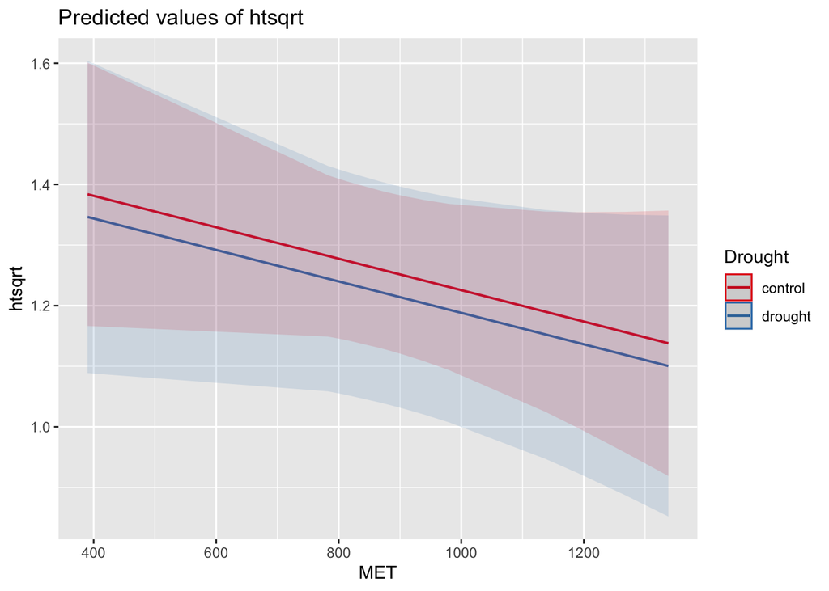

```r
plot_model(ohia.met.dr, type = "pred", terms=c("MET","Drought"))
```

*Be sure to include Block in your models, and think about which terms in the model should be random effects, which should be fixed effects, which should be fixed:random interactions, and which should be fixed:fixed interactions (you will need all four).*

*Make appropriate plots of model results and describe the magnitude of any apparent relationships.*

I added them up with the models.

# 2.

### Mortality

*Using the seedlings that were fated to be harvested after the press drought treatment,analyze how survival during the press drought is affected by the various potential predictors.*

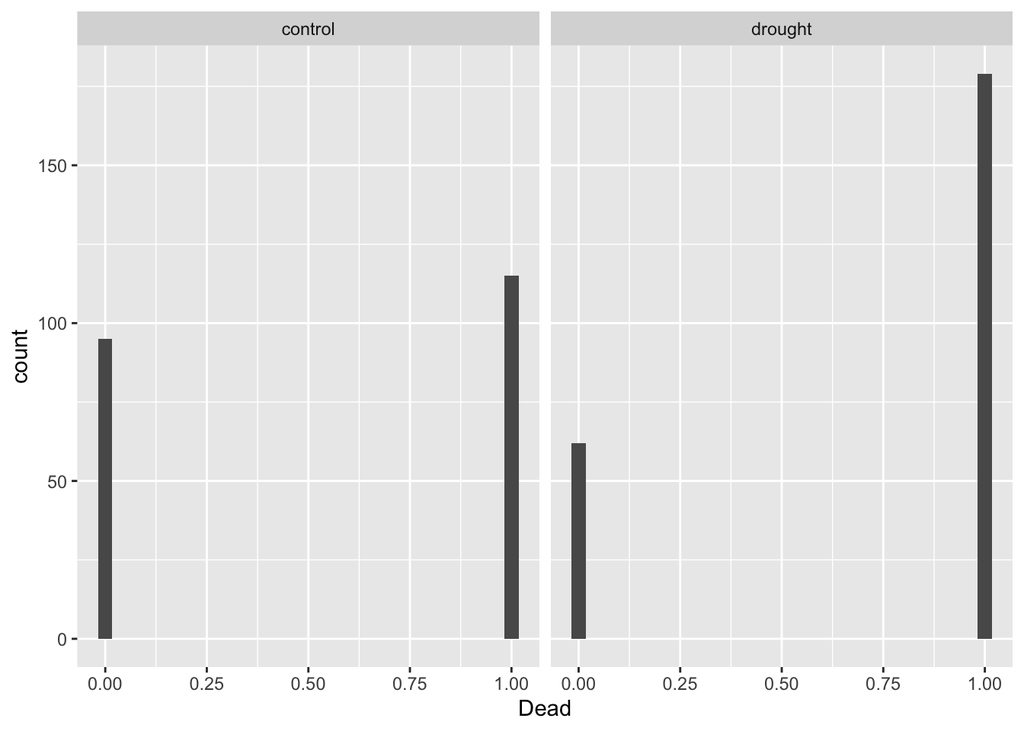

```r
ohia_s<- ohia_raw %>%
  filter(Fate=="harvest")

ohia_s$Drought<-as.factor(ohia_s$Drought)

height <- ggplot(ohia_s, aes(x=Dead))+
  geom_histogram()+
  facet_wrap(~Drought)
height
```

1= DEAD, 0=ALIVE!

*set up models to test*

*whether populations vary in probability of mortality (i.e., the response column DEAD)*

```r
ohia.s.pop = glmer(Dead ~ Population + (1|Block), data = ohia_s, family = binomial)
summary(ohia.s.pop)
```

```
## Generalized linear mixed model fit by maximum likelihood (Laplace
##   Approximation) [glmerMod]
##  Family: binomial  ( logit )
## Formula: Dead ~ Population + (1 | Block)
##    Data: ohia_s
##
##      AIC      BIC   logLik deviance df.resid
##    544.3    614.2   -255.1    510.3      434
##
## Scaled residuals:
##     Min      1Q  Median      3Q     Max
## -3.1912 -0.8434  0.3937  0.6487  1.6769
##
## Random effects:
##  Groups Name        Variance Std.Dev.
##  Block  (Intercept) 0.7548   0.8688
## Number of obs: 451, groups:  Block, 9
##
## Fixed effects:
##                     Estimate Std. Error z value Pr(>|z|)
## (Intercept)          0.12623    0.88349   0.143   0.8864
## PopulationKuaokala   1.21273    1.12321   1.080   0.2803
## PopulationKuliouou   1.06242    1.26284   0.841   0.4002
## PopulationManana1    0.66531    1.10853   0.600   0.5484
## PopulationManana2    2.80297    1.19676   2.342   0.0192 *
## PopulationMaumae     0.86607    1.06638   0.812   0.4167
## PopulationMokuleia3  1.54853    1.25480   1.234   0.2172
## PopulationPalikea    0.96402    1.42589   0.676   0.4990
## PopulationPauoa1     1.01749    0.71511   1.423   0.1548
## PopulationPoamoho2   1.05107    1.00633   1.044   0.2963
## PopulationPoamoho3   1.57307    1.09058   1.442   0.1492
## PopulationPTAA      -1.03704    0.63826  -1.625   0.1042
## PopulationPTAB      -1.04684    1.32022  -0.793   0.4278
## PopulationWaahila1   0.69345    1.02033   0.680   0.4967
## PopulationWaahila2   0.02102    1.13686   0.018   0.9852
## PopulationWaimano    1.95127    1.57148   1.242   0.2144
## ---
## Signif. codes:  0 '***' 0.001 '**' 0.01 '*' 0.05 '.' 0.1 ' ' 1
```

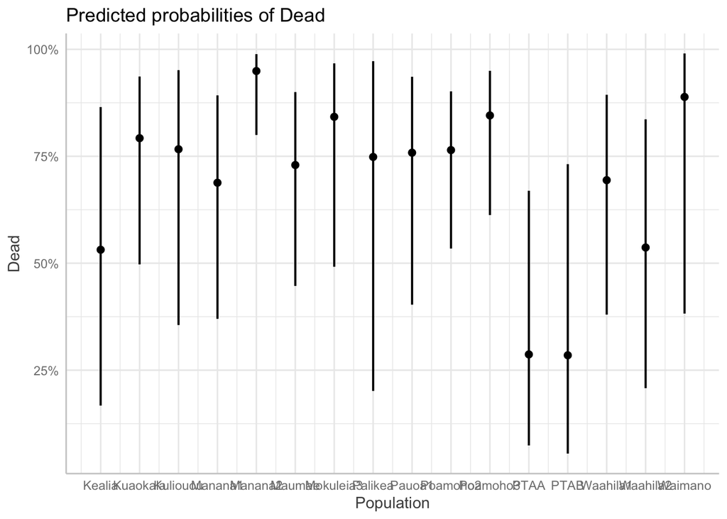

```r
plot(ggeffect(ohia.s.pop, terms = c('Population')))
```

There’s variation by site at Manana 2, but not anywhere else significantly. It looks like block explains a lot of variation.

*whether the press drought treatment affects mean mortality*

```r
ohia.s.dr = glmer(Dead ~ Drought + (1|Block), data = ohia_s, family = binomial)
summary(ohia.s.dr)
```

```
## Generalized linear mixed model fit by maximum likelihood (Laplace
##   Approximation) [glmerMod]
##  Family: binomial  ( logit )
## Formula: Dead ~ Drought + (1 | Block)
##    Data: ohia_s
##
##      AIC      BIC   logLik deviance df.resid
##    525.6    537.9   -259.8    519.6      448
##
## Scaled residuals:
##     Min      1Q  Median      3Q     Max
## -3.8278 -0.8935  0.3264  0.6181  1.8382
##
## Random effects:
##  Groups Name        Variance Std.Dev.
##  Block  (Intercept) 1.252    1.119
## Number of obs: 451, groups:  Block, 9
##
## Fixed effects:
##                Estimate Std. Error z value Pr(>|z|)
## (Intercept)      0.4472     0.4132   1.082    0.279
## Droughtdrought   1.0067     0.2196   4.584 4.57e-06 ***
## ---
## Signif. codes:  0 '***' 0.001 '**' 0.01 '*' 0.05 '.' 0.1 ' ' 1
##
## Correlation of Fixed Effects:
##             (Intr)
## Droghtdrght -0.236
```

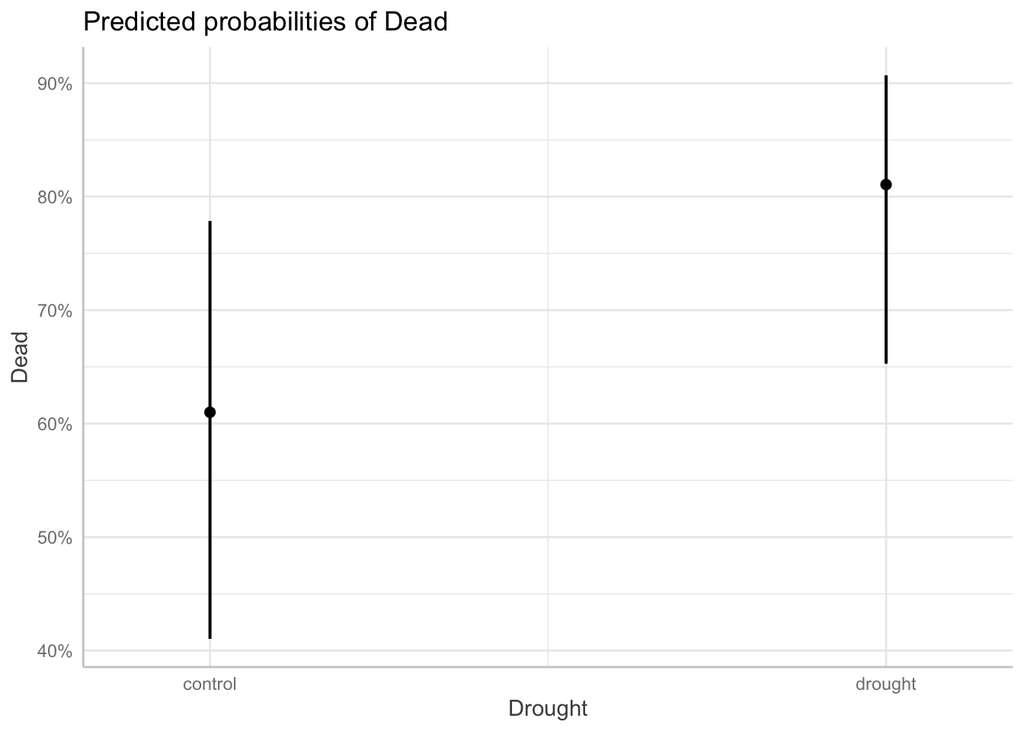

```r
plot(ggeffect(ohia.s.dr, terms = c('Drought')))
```

hey here we go!

```r
exp(0.44)/(1 + exp(0.44))# probability control has of dying
```

```
## [1] 0.608259
```

```r
exp(1.4)/(1 + exp(1.4))  #probability drought has of dying
```

```
## [1] 0.8021839
```

```r
exp(1.0067)
```

```
## [1] 2.736555
```

*whether populations vary in how mortality is affected by the press drought treatment.*

```r
ohia.s.int= glmer(Dead ~ Drought + (Drought|Population) + (1|Block), data = ohia_s, family = binomial)

summary(ohia.s.int)
```

```
## Generalized linear mixed model fit by maximum likelihood (Laplace
##   Approximation) [glmerMod]
##  Family: binomial  ( logit )
## Formula: Dead ~ Drought + (Drought | Population) + (1 | Block)
##    Data: ohia_s
##
##      AIC      BIC   logLik deviance df.resid
##    525.4    550.0   -256.7    513.4      445
##
## Scaled residuals:
##     Min      1Q  Median      3Q     Max
## -3.3439 -0.8278  0.3393  0.5974  1.7268
##
## Random effects:
##  Groups     Name           Variance Std.Dev. Corr
##  Population (Intercept)    0.1692   0.4113
##             Droughtdrought 0.1654   0.4067   0.43
##  Block      (Intercept)    1.1596   1.0769
## Number of obs: 451, groups:  Population, 16; Block, 9
##
## Fixed effects:
##                Estimate Std. Error z value Pr(>|z|)
## (Intercept)      0.4492     0.4181   1.074    0.283
## Droughtdrought   1.0243     0.2498   4.101 4.12e-05 ***
## ---
## Signif. codes:  0 '***' 0.001 '**' 0.01 '*' 0.05 '.' 0.1 ' ' 1
##
## Correlation of Fixed Effects:
##             (Intr)
## Droghtdrght -0.169
```

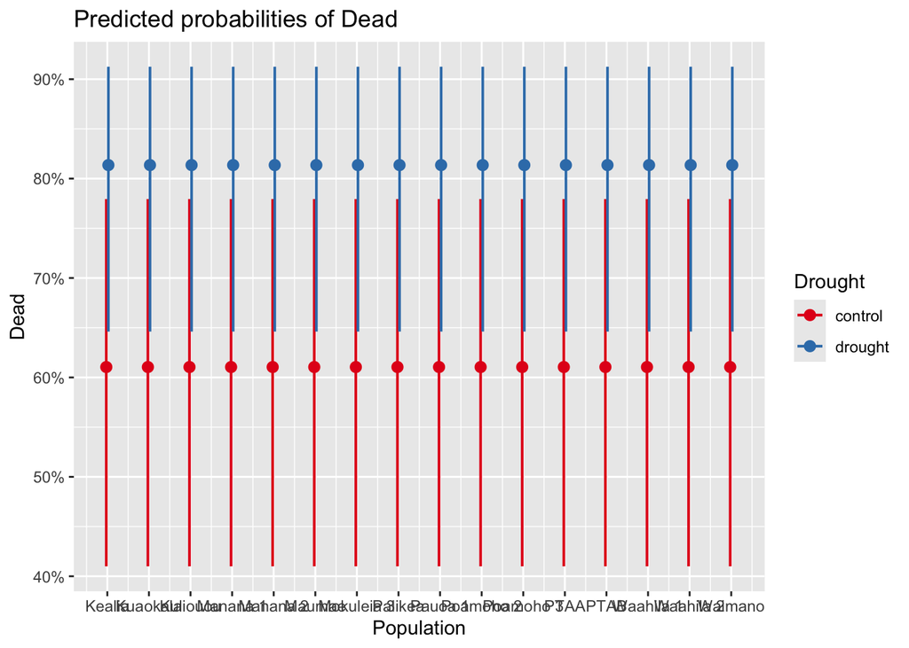

```r
plot_model(ohia.s.int, type= "pred", terms = c('Population','Drought'))
```

```r
exp(1.47)
```

```
## [1] 4.349235
```

*set up models to test*

*whether historical rainfall at a site predicts mortality*

```r
ohia_s$MAR_scaled <- scale(ohia_s$MAR)
ohia.s.mar= glmer(Dead ~ MAR_scaled + (1|Block), data = ohia_s, family = binomial)
summary(ohia.s.mar)
```

```
## Generalized linear mixed model fit by maximum likelihood (Laplace
##   Approximation) [glmerMod]
##  Family: binomial  ( logit )
## Formula: Dead ~ MAR_scaled + (1 | Block)
##    Data: ohia_s
##
##      AIC      BIC   logLik deviance df.resid
##    532.5    544.9   -263.3    526.5      448
##
## Scaled residuals:
##     Min      1Q  Median      3Q     Max
## -3.1572 -0.8204  0.4233  0.6461  1.4256
##
## Random effects:
##  Groups Name        Variance Std.Dev.
##  Block  (Intercept) 0.9594   0.9795
## Number of obs: 451, groups:  Block, 9
##
## Fixed effects:
##             Estimate Std. Error z value Pr(>|z|)
## (Intercept)   0.9874     0.3589   2.751 0.005934 **
## MAR_scaled    0.5415     0.1429   3.790 0.000151 ***
## ---
## Signif. codes:  0 '***' 0.001 '**' 0.01 '*' 0.05 '.' 0.1 ' ' 1
##
## Correlation of Fixed Effects:
##            (Intr)
## MAR_scaled 0.062
```

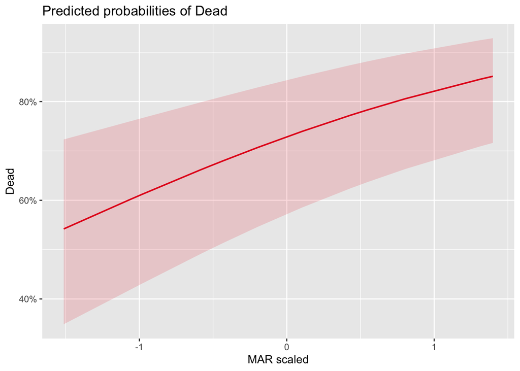

```r
plot_model(ohia.s.mar, type= "pred", terms = c('MAR_scaled'))
```

Okay. It looks like 1) Block alone explains a large portion of the variation in this model, 2) MAR has a positive effect on the baseline (.54 log odds), which means that higher rainfall means youʻre more likely to die? Yeah I guess so.

*whether historical rainfall at a site predicts the effect of press drought on mortality.*

```r
ohia.s.mar.int= glmer(Dead ~ MAR_scaled*Drought + (1|Block), data = ohia_s, family = binomial)
summary(ohia.s.mar.int)
```

```
## Generalized linear mixed model fit by maximum likelihood (Laplace
##   Approximation) [glmerMod]
##  Family: binomial  ( logit )
## Formula: Dead ~ MAR_scaled * Drought + (1 | Block)
##    Data: ohia_s
##
##      AIC      BIC   logLik deviance df.resid
##    514.4    534.9   -252.2    504.4      446
##
## Scaled residuals:
##     Min      1Q  Median      3Q     Max
## -4.4001 -0.8110  0.3757  0.5858  1.7394
##
## Random effects:
##  Groups Name        Variance Std.Dev.
##  Block  (Intercept) 1.042    1.021
## Number of obs: 451, groups:  Block, 9
##
## Fixed effects:
##                           Estimate Std. Error z value Pr(>|z|)
## (Intercept)                 0.4951     0.3850   1.286   0.1985
## MAR_scaled                  0.4453     0.1799   2.476   0.0133 *
## Droughtdrought              1.0235     0.2243   4.563 5.05e-06 ***
## MAR_scaled:Droughtdrought   0.2216     0.2226   0.996   0.3194
## ---
## Signif. codes:  0 '***' 0.001 '**' 0.01 '*' 0.05 '.' 0.1 ' ' 1
##
## Correlation of Fixed Effects:
##             (Intr) MAR_sc Drghtd
## MAR_scaled   0.032
## Droghtdrght -0.249  0.025
## MAR_scld:Dr  0.004 -0.567  0.065
```

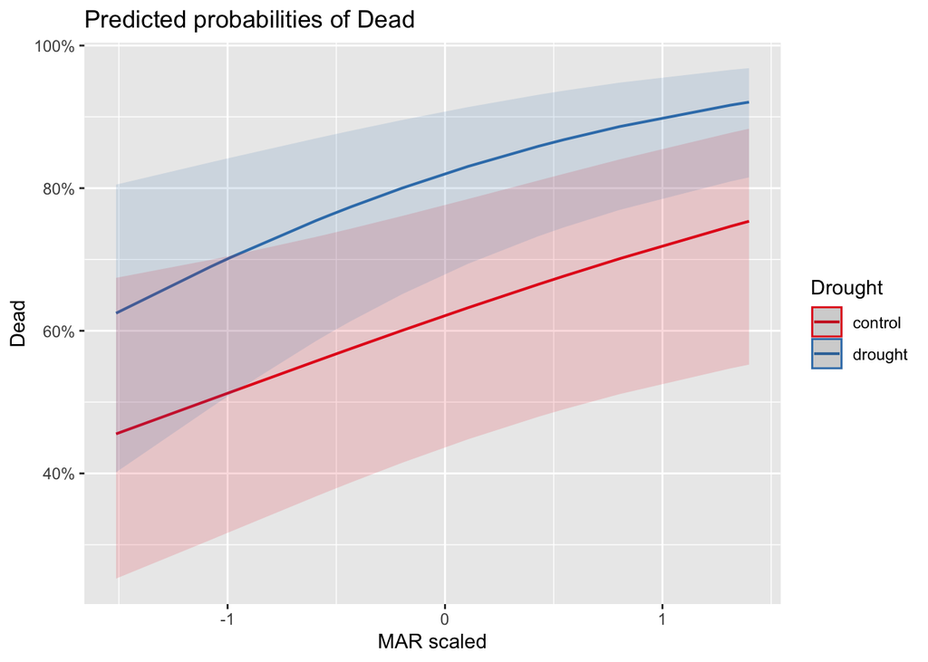

```r
plot_model(ohia.s.mar.int, type= "pred", terms = c('MAR_scaled','Drought'))
```

Well, I don’t know if I did this one right– it looks like you can predict the drought mortality of a site based on the MAR? higher MAR is .44 log-odds more likely to cause mortality, but drought is 1.02 log odds more likely to cause mortality no matter the interaction. Seems… I don’t know. Seems like more historical rainfall, if it means more mortality on its own, would be kind of ramped up if drought is introduced. But I guess this is saying that drought death has similar log odds regardless of MAR?

*Finally, set up models to test:*

*whether historical evapotranspiration at a site predicts mortality*

```r
ohia_s$MET_scaled <- scale(ohia_s$MET)
ohia.s.met= glmer(Dead ~ MET_scaled + (1|Block), data = ohia_s, family = binomial)
summary(ohia.s.met)
```

```
## Generalized linear mixed model fit by maximum likelihood (Laplace
##   Approximation) [glmerMod]
##  Family: binomial  ( logit )
## Formula: Dead ~ MET_scaled + (1 | Block)
##    Data: ohia_s
##
##      AIC      BIC   logLik deviance df.resid
##    540.0    552.3   -267.0    534.0      448
##
## Scaled residuals:
##     Min      1Q  Median      3Q     Max
## -3.3455 -1.0896  0.4083  0.7718  1.4464
##
## Random effects:
##  Groups Name        Variance Std.Dev.
##  Block  (Intercept) 0.9147   0.9564
## Number of obs: 451, groups:  Block, 9
##
## Fixed effects:
##             Estimate Std. Error z value Pr(>|z|)
## (Intercept)   0.9832     0.3511   2.800  0.00510 **
## MET_scaled    0.3485     0.1308   2.665  0.00769 **
## ---
## Signif. codes:  0 '***' 0.001 '**' 0.01 '*' 0.05 '.' 0.1 ' ' 1
##
## Correlation of Fixed Effects:
##            (Intr)
## MET_scaled 0.056
```

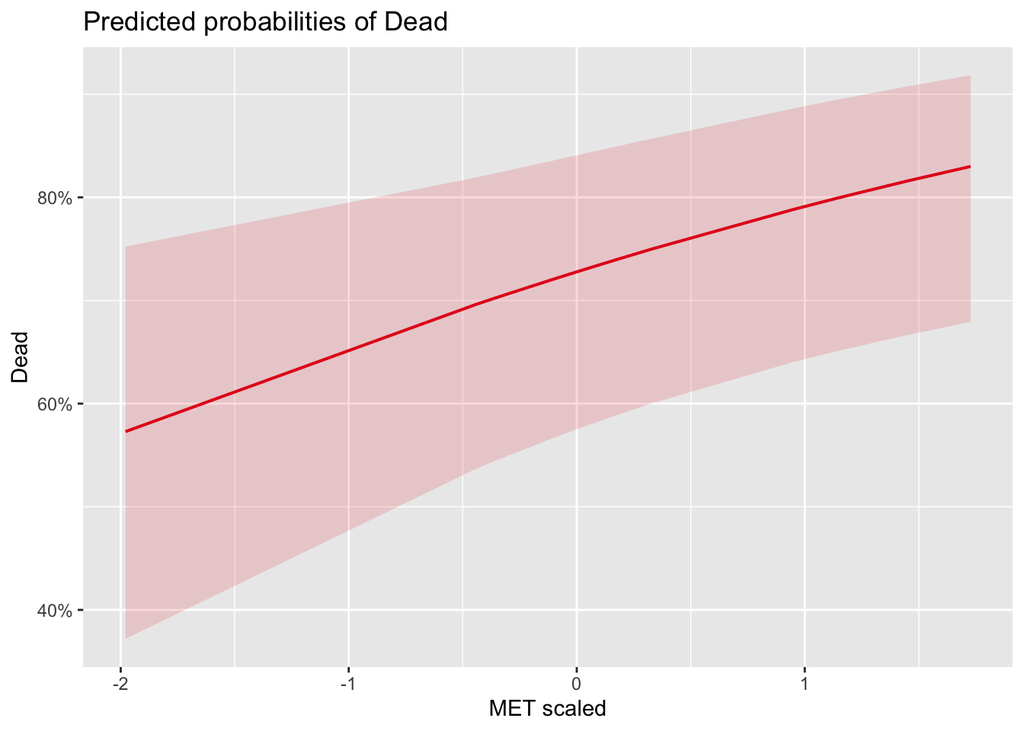

```r
plot_model(ohia.s.met, type= "pred", terms = c('MET_scaled'))
```

yup, it looks like increased MET_scaled is .34 log-odds more likely to cause mortality than average MET.

*whether historical evapotranspiration at a site predicts the effect of press drought on mortality.*

```r
ohia.s.met.int= glmer(Dead ~ MET_scaled*Drought + (1|Block), data = ohia_s, family = binomial)
summary(ohia.s.met.int)
```

```
## Generalized linear mixed model fit by maximum likelihood (Laplace
##   Approximation) [glmerMod]
##  Family: binomial  ( logit )
## Formula: Dead ~ MET_scaled * Drought + (1 | Block)
##    Data: ohia_s
##
##      AIC      BIC   logLik deviance df.resid
##    519.5    540.0   -254.7    509.5      446
##
## Scaled residuals:
##     Min      1Q  Median      3Q     Max
## -3.7270 -0.8090  0.3557  0.6462  1.5611
##
## Random effects:
##  Groups Name        Variance Std.Dev.
##  Block  (Intercept) 0.9955   0.9977
## Number of obs: 451, groups:  Block, 9
##
## Fixed effects:
##                           Estimate Std. Error z value Pr(>|z|)
## (Intercept)                 0.5020     0.3772   1.331   0.1832
## MET_scaled                  0.1599     0.1688   0.947   0.3435
## Droughtdrought              1.0077     0.2220   4.539 5.64e-06 ***
## MET_scaled:Droughtdrought   0.3832     0.2129   1.800   0.0719 .
## ---
## Signif. codes:  0 '***' 0.001 '**' 0.01 '*' 0.05 '.' 0.1 ' ' 1
##
## Correlation of Fixed Effects:
##             (Intr) MET_sc Drghtd
## MET_scaled   0.036
## Droghtdrght -0.252  0.006
## MET_scld:Dr  0.008 -0.591  0.031
```

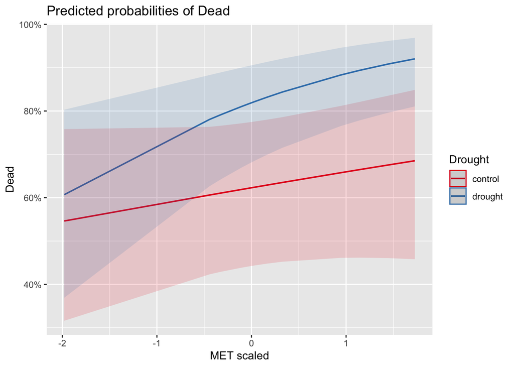

```r
plot_model(ohia.s.met.int, type= "pred", terms = c('MET_scaled','Drought'))
```

Hey well lookie there. It looks like there might be a slight interaction between MET and Drought. That makes sense! That makes SENSE! So plants that are already in high MET areas might have an increased response to drought, but drought is still bad across the board.

*Be sure to think about what the appropriate probability distribution is for the response variable.* This would be a bionimal distribution, and it’s the log-odds of dying.

*How do you interpret the results?* Phhht. PHHHHT. I think drought bad. However, it looks like it’s not that bad when it comes to height, but it’s bad for mortality. Higher annual rainfall means that plants are more likely to die (maybe because it’s wet and things are rotting faster? I dunno), but drought does not make them -more- likely to die than plants with lower MAR. Plants with higher MET however may be slightly more vulnerable to drought. I feel like this was not in the paper and I have done something egregious.

# 3.

*Using the seedlings that were fated for the terminal drought experiment (i.e., the seedlings that were not harvested), analyze how longevity during terminal drought is affected by the various potential predictors.*

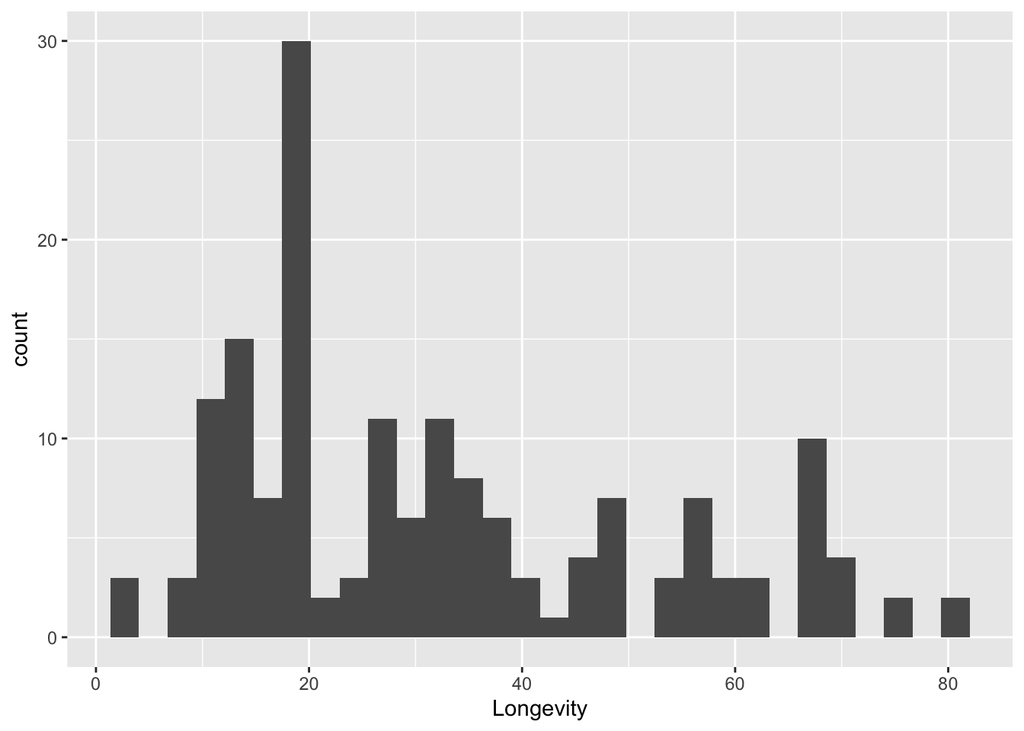

```r
ohia_t <- ohia_raw %>%
  filter(Fate=="terminaldrought")

ohia_t$MAR_scaled <- scale(ohia_t$MAR)
ohia_t$MET_scaled <- scale(ohia_t$MET)

longie <- ggplot(ohia_t, aes(x=Longevity))+
  geom_histogram()
longie
```

This… looks overdispersed. It also might count as count data since it’s days in integers

*Specifically, set up models to test:*

This is all to try to pick a good distribution so I can avoid overdispersion:

```r
ohia.t.pop <- glmer(Longevity ~ Population + (1|Block), family = poisson, data = ohia_t)
overdisp.glmer(ohia.t.pop) #Sucks
```

```
## Residual deviance: 523.323 on 150 degrees of freedom (ratio: 3.489)
```

```r
ohia.t.id <- glmer(Longevity ~ Population + (1|Block)+(1|ID), family = poisson, data = ohia_t)
overdisp.glmer(ohia.t.id) # Convergence problem!
```

```
## Residual deviance: 63.795 on 149 degrees of freedom (ratio: 0.428)
```

```r
ohia.t.nb.pop = glmer.nb(Longevity ~ Population + (1|Block), data = ohia_t)
overdisp.glmer(ohia.t.nb.pop) #No convergence problem, overdispersion is at 1.2
```

```
## Residual deviance: 177.867 on 150 degrees of freedom (ratio: 1.186)
```

*whether populations vary in longevity,*

```r
ohia.t.nb.pop = glmer.nb(Longevity ~ Population + (1|Block), data = ohia_t)

summary(ohia.t.nb.pop)
```

```
## Generalized linear mixed model fit by maximum likelihood (Laplace
##   Approximation) [glmerMod]
##  Family: Negative Binomial(11.1691)  ( log )
## Formula: Longevity ~ Population + (1 | Block)
##    Data: ohia_t
##
##      AIC      BIC   logLik deviance df.resid
##   1273.7   1326.6   -619.9   1239.7      149
##
## Scaled residuals:
##     Min      1Q  Median      3Q     Max
## -2.0775 -0.6129 -0.0081  0.6036  4.2296
##
## Random effects:
##  Groups Name        Variance  Std.Dev.
##  Block  (Intercept) 1.489e-17 3.859e-09
## Number of obs: 166, groups:  Block, 9
##
## Fixed effects:
##                     Estimate Std. Error z value Pr(>|z|)
## (Intercept)          2.89653    0.12682  22.840  < 2e-16 ***
## PopulationKuaokala   0.30400    0.16711   1.819   0.0689 .
## PopulationKuliouou   0.77661    0.17450   4.451 8.57e-06 ***
## PopulationManana1    0.63782    0.16394   3.891 1.00e-04 ***
## PopulationManana2    0.06875    0.21047   0.327   0.7439
## PopulationMaumae     0.05167    0.16194   0.319   0.7497
## PopulationMokuleia3  0.57544    0.20050   2.870   0.0041 **
## PopulationPalikea   -0.18848    0.41507  -0.454   0.6498
## PopulationPauoa1    -0.16216    0.17757  -0.913   0.3611
## PopulationPoamoho2   0.24475    0.15790   1.550   0.1211
## PopulationPoamoho3  -0.01359    0.16057  -0.085   0.9326
## PopulationPTAA       0.73187    0.14536   5.035 4.79e-07 ***
## PopulationPTAB       1.26773    0.14038   9.031  < 2e-16 ***
## PopulationWaahila1  -0.18848    0.21754  -0.866   0.3863
## PopulationWaahila2   0.24763    0.20642   1.200   0.2303
## ---
## Signif. codes:  0 '***' 0.001 '**' 0.01 '*' 0.05 '.' 0.1 ' ' 1
```

```
## optimizer (Nelder_Mead) convergence code: 0 (OK)
## boundary (singular) fit: see help('isSingular')
```

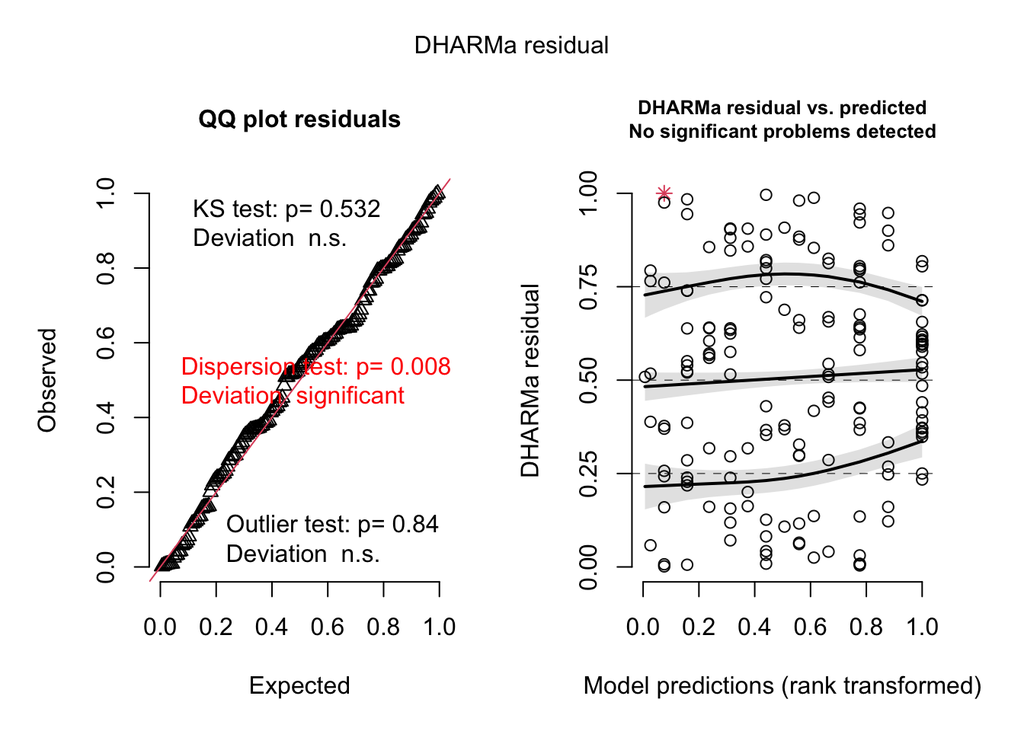

```r
# DHARMa
res <- simulateResiduals(fittedModel = ohia.t.nb.pop)
plot(res)
```

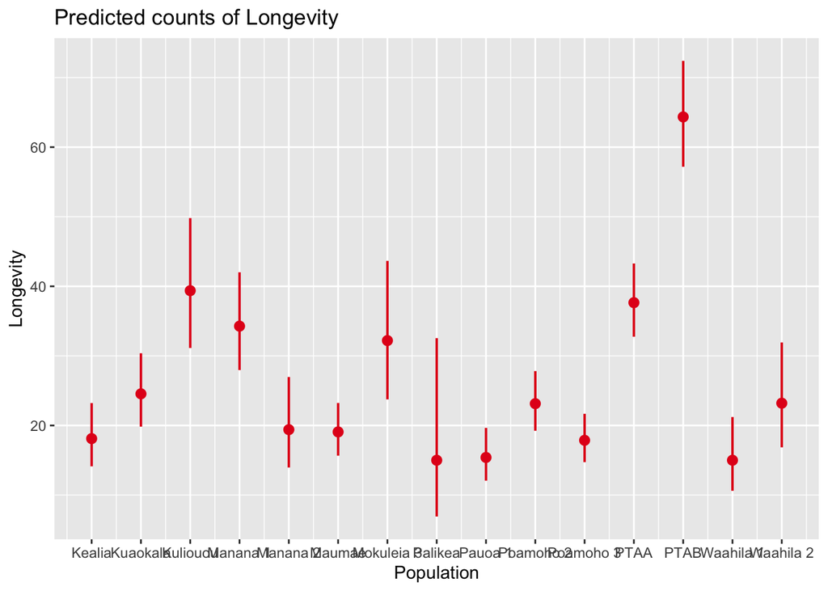

```r
#I do not understand why this QQ plot is mad at me since it looks pretty good.The residual v. predicted looks worse to me.

plot_model(ohia.t.nb.pop, type = "pred", terms=c("Population"))
```

Even though I’m getting a warning that Block has really low variance, I’m going to keep it anyway since it’s part of the experimental design. Some populations do vary in longevity, though the majority live between like 15-40 days. It looks like some populations (all the significant ones) last longer than the intercept, which is good for those there trees:

```r
exp(fixef(ohia.t.nb.pop))
```

```
##         (Intercept)  PopulationKuaokala  PopulationKuliouou   PopulationManana1
##          18.1111111           1.3552705           2.1740798           1.8923592
##   PopulationManana2    PopulationMaumae PopulationMokuleia3   PopulationPalikea
##           1.0711656           1.0530237           1.7779141           0.8282209
##    PopulationPauoa1  PopulationPoamoho2  PopulationPoamoho3      PopulationPTAA
##           0.8503068           1.2773006           0.9865031           2.0789544
##      PopulationPTAB  PopulationWaahila1  PopulationWaahila2
##           3.5527819           0.8282209           1.2809816
```

*whether the press drought treatment affects longevity,*

```r
ohia.t.nb.dr = glmer.nb(Longevity ~ Drought + (1|Block), data = ohia_t)
summary(ohia.t.nb.dr)
```

```
## Generalized linear mixed model fit by maximum likelihood (Laplace
##   Approximation) [glmerMod]
##  Family: Negative Binomial(7.1128)  ( log )
## Formula: Longevity ~ Drought + (1 | Block)
##    Data: ohia_t
##
##      AIC      BIC   logLik deviance df.resid
##   1325.3   1337.7   -658.6   1317.3      162
##
## Scaled residuals:
##     Min      1Q  Median      3Q     Max
## -1.9517 -0.7414 -0.0673  0.6254  3.2413
##
## Random effects:
##  Groups Name        Variance Std.Dev.
##  Block  (Intercept) 0.2421   0.492
## Number of obs: 166, groups:  Block, 9
##
## Fixed effects:
##                Estimate Std. Error z value Pr(>|z|)
## (Intercept)     3.26005    0.17378  18.760   <2e-16 ***
## Droughtdrought  0.06528    0.06751   0.967    0.334
## ---
## Signif. codes:  0 '***' 0.001 '**' 0.01 '*' 0.05 '.' 0.1 ' ' 1
##
## Correlation of Fixed Effects:
##             (Intr)
## Droghtdrght -0.144
```

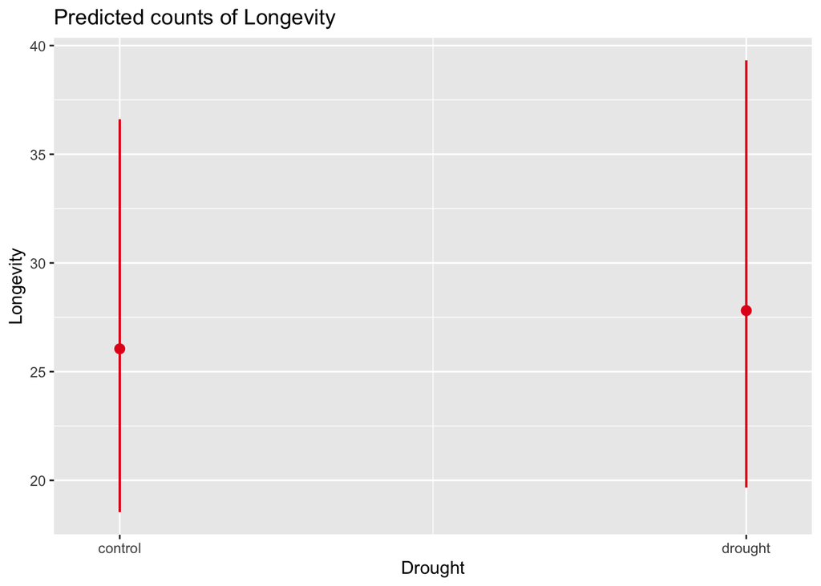

```r
plot_model(ohia.t.nb.dr, type = "pred", terms=c("Drought"))
```

wowzers! Well, I guess drought doesn’t impact longevity. So if you can (generally) survive the drought, you can keep going?

*whether populations vary in how longevity is affected by the press drought treatment.*

I’m worried my nested random effect model is overfitting now… uh, I guess i’ll take it out here? I am being inconsistent.

```r
ohia.t.nb.int = glmer.nb(Longevity ~ Drought +(Drought|Population)+ (1|Block), data = ohia_t)
summary(ohia.t.nb.int)
```

```
## Generalized linear mixed model fit by maximum likelihood (Laplace
##   Approximation) [glmerMod]
##  Family: Negative Binomial(11.1248)  ( log )
## Formula: Longevity ~ Drought + (Drought | Population) + (1 | Block)
##    Data: ohia_t
##
##      AIC      BIC   logLik deviance df.resid
##   1296.7   1318.5   -641.4   1282.7      159
##
## Scaled residuals:
##      Min       1Q   Median       3Q      Max
## -2.08311 -0.69247 -0.01922  0.51984  3.11048
##
## Random effects:
##  Groups     Name           Variance Std.Dev. Corr
##  Population (Intercept)    0.091722 0.30286
##             Droughtdrought 0.007119 0.08437  -0.58
##  Block      (Intercept)    0.167872 0.40972
## Number of obs: 166, groups:  Population, 15; Block, 9
##
## Fixed effects:
##                Estimate Std. Error z value Pr(>|z|)
## (Intercept)     3.23996    0.16723  19.375   <2e-16 ***
## Droughtdrought  0.03667    0.06895   0.532    0.595
## ---
## Signif. codes:  0 '***' 0.001 '**' 0.01 '*' 0.05 '.' 0.1 ' ' 1
##
## Correlation of Fixed Effects:
##             (Intr)
## Droghtdrght -0.201
```

No, populations don’t really vary in how longevity is impacted by drought.

*Next, set up models to test:*

*whether historical rainfall at a site predicts longevity*

```r
ohia.mar.nb= glmer.nb(Longevity ~ MAR_scaled + (1|Population) + (1|Block), data = ohia_t)
summary(ohia.mar.nb)
```

```
## Generalized linear mixed model fit by maximum likelihood (Laplace
##   Approximation) [glmerMod]
##  Family: Negative Binomial(10.875)  ( log )
## Formula: Longevity ~ MAR_scaled + (1 | Population) + (1 | Block)
##    Data: ohia_t
##
##      AIC      BIC   logLik deviance df.resid
##   1288.0   1303.5   -639.0   1278.0      161
##
## Scaled residuals:
##     Min      1Q  Median      3Q     Max
## -2.0387 -0.6777 -0.0521  0.5504  3.2204
##
## Random effects:
##  Groups     Name        Variance Std.Dev.
##  Population (Intercept) 0.04979  0.2231
##  Block      (Intercept) 0.13665  0.3697
## Number of obs: 166, groups:  Population, 15; Block, 9
##
## Fixed effects:
##             Estimate Std. Error z value Pr(>|z|)
## (Intercept)  3.28659    0.14528  22.623   <2e-16 ***
## MAR_scaled  -0.23217    0.09096  -2.552   0.0107 *
## ---
## Signif. codes:  0 '***' 0.001 '**' 0.01 '*' 0.05 '.' 0.1 ' ' 1
##
## Correlation of Fixed Effects:
##            (Intr)
## MAR_scaled -0.070
```

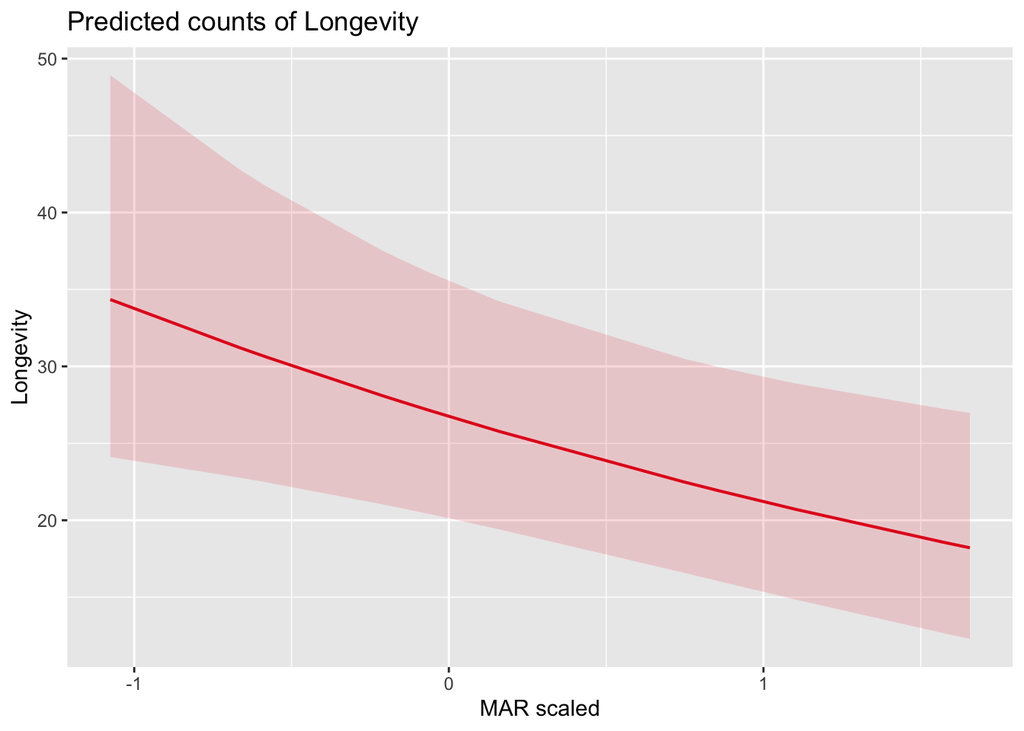

```r
plot_model(ohia.mar.nb, type = "pred", terms=c("MAR_scaled"))
```

```r
exp(-0.232)
```

```
## [1] 0.7929461
```

*whether historical rainfall at a site predicts the effect of press drought on longevity.*

```r
ohia.mar.nb.dr = glmer.nb(Longevity ~ MAR_scaled *Drought+ (1|Population) + (1|Block), data = ohia_t)
summary(ohia.mar.nb.dr)
```

```
## Generalized linear mixed model fit by maximum likelihood (Laplace
##   Approximation) [glmerMod]
##  Family: Negative Binomial(11.1575)  ( log )
## Formula: Longevity ~ MAR_scaled * Drought + (1 | Population) + (1 | Block)
##    Data: ohia_t
##
##      AIC      BIC   logLik deviance df.resid
##   1289.2   1311.0   -637.6   1275.2      159
##
## Scaled residuals:
##     Min      1Q  Median      3Q     Max
## -2.0926 -0.7385 -0.0756  0.5924  3.3840
##
## Random effects:
##  Groups     Name        Variance Std.Dev.
##  Population (Intercept) 0.04506  0.2123
##  Block      (Intercept) 0.16060  0.4007
## Number of obs: 166, groups:  Population, 15; Block, 9
##
## Fixed effects:
##                           Estimate Std. Error z value Pr(>|z|)
## (Intercept)                3.28328    0.15415  21.300  < 2e-16 ***
## MAR_scaled                -0.27049    0.09147  -2.957  0.00311 **
## Droughtdrought             0.04111    0.06014   0.684  0.49424
## MAR_scaled:Droughtdrought  0.10112    0.06174   1.638  0.10147
## ---
## Signif. codes:  0 '***' 0.001 '**' 0.01 '*' 0.05 '.' 0.1 ' ' 1
##
## Correlation of Fixed Effects:
##             (Intr) MAR_sc Drghtd
## MAR_scaled  -0.069
## Droghtdrght -0.120 -0.029
## MAR_scld:Dr  0.012 -0.264  0.225
```

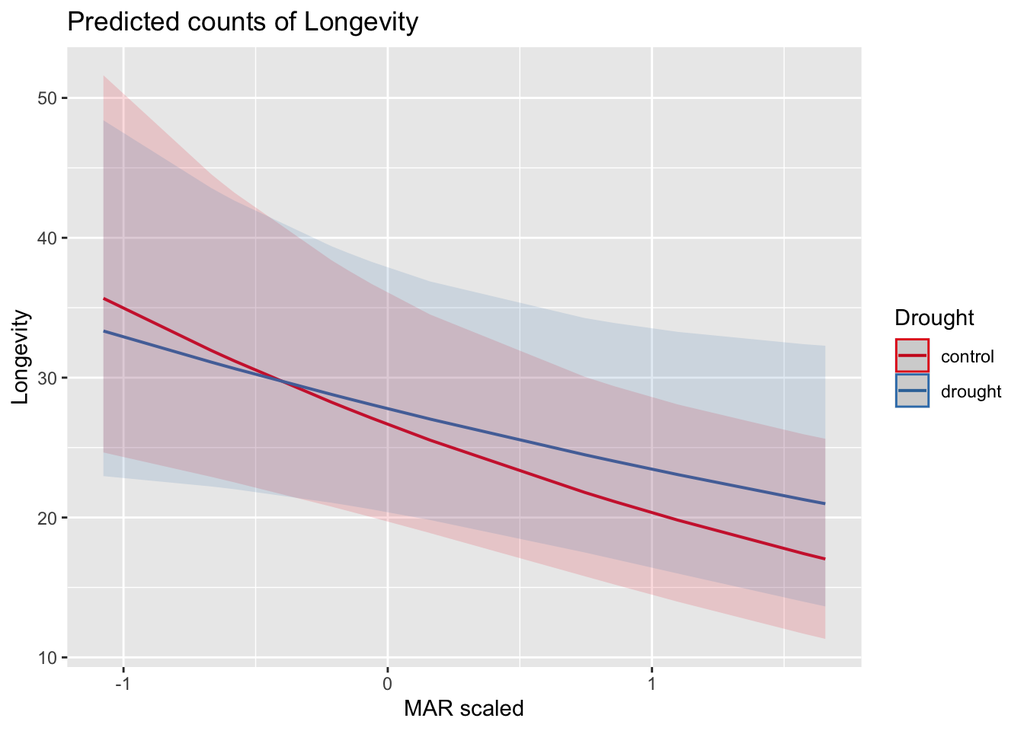

```r
plot_model(ohia.mar.nb.dr, type = "pred", terms=c("MAR_scaled","Drought"))
```

Well God Bless America I guess MAR does not predict the effect of drought! Still we are getting a negative effect for MAR, but Drought and the interaction between MAR and drought is not significant. It is interesting to see the steeper slope for the control group though, which maybe suggests that drought effects aren’t as bad in areas with higher rainfall. That would make sense.

*Finally, set up models to test:*

*whether historical evapotranspiration at a site predicts longevity*

```r
ohia.met.nb.all= glmer.nb(Longevity ~ MET_scaled + Population + (1|Block), data = ohia_t)
summary(ohia.met.nb.all) #just lookin' to see which sites
```

```
## Generalized linear mixed model fit by maximum likelihood (Laplace
##   Approximation) [glmerMod]
##  Family: Negative Binomial(11.1691)  ( log )
## Formula: Longevity ~ MET_scaled + Population + (1 | Block)
##    Data: ohia_t
##
##      AIC      BIC   logLik deviance df.resid
##   1273.7   1326.6   -619.9   1239.7      149
##
## Scaled residuals:
##     Min      1Q  Median      3Q     Max
## -2.0775 -0.6129 -0.0081  0.6036  4.2296
##
## Random effects:
##  Groups Name        Variance  Std.Dev.
##  Block  (Intercept) 4.024e-18 2.006e-09
## Number of obs: 166, groups:  Block, 9
##
## Fixed effects:
##                     Estimate Std. Error z value Pr(>|z|)
## (Intercept)          3.12553    0.15093  20.709   <2e-16 ***
## MET_scaled          -0.23505    0.19593  -1.200   0.2303
## PopulationKuaokala   0.07564    0.18574   0.407   0.6838
## PopulationKuliouou   0.52327    0.20528   2.549   0.0108 *
## PopulationManana1    0.78126    0.24455   3.195   0.0014 **
## PopulationManana2   -0.12250    0.21183  -0.578   0.5631
## PopulationMaumae     0.08877    0.17889   0.496   0.6197
## PopulationMokuleia3  0.34066    0.21910   1.555   0.1200
## PopulationPalikea   -0.35332    0.41201  -0.858   0.3911
## PopulationPauoa1    -0.06939    0.22262  -0.312   0.7553
## PopulationPoamoho2   0.05421    0.15941   0.340   0.7338
## PopulationPoamoho3  -0.12563    0.14125  -0.889   0.3738
## PopulationPTAA       0.19879    0.38646   0.514   0.6070
## PopulationPTAB       0.73466    0.38461   1.910   0.0561 .
## PopulationWaahila1  -0.33049    0.20710  -1.596   0.1105
## ---
## Signif. codes:  0 '***' 0.001 '**' 0.01 '*' 0.05 '.' 0.1 ' ' 1
```

```
## fit warnings:
## fixed-effect model matrix is rank deficient so dropping 1 column / coefficient
## optimizer (Nelder_Mead) convergence code: 0 (OK)
## boundary (singular) fit: see help('isSingular')
```

```r
ohia.met.nb= glmer.nb(Longevity ~ MET_scaled + (1|Population) + (1|Block), data = ohia_t)
summary(ohia.met.nb)
```

```
## Generalized linear mixed model fit by maximum likelihood (Laplace
##   Approximation) [glmerMod]
##  Family: Negative Binomial(10.7843)  ( log )
## Formula: Longevity ~ MET_scaled + (1 | Population) + (1 | Block)
##    Data: ohia_t
##
##      AIC      BIC   logLik deviance df.resid
##   1288.8   1304.4   -639.4   1278.8      161
##
## Scaled residuals:
##     Min      1Q  Median      3Q     Max
## -2.0753 -0.7078  0.0059  0.5802  3.2838
##
## Random effects:
##  Groups     Name        Variance Std.Dev.
##  Population (Intercept) 0.06662  0.2581
##  Block      (Intercept) 0.09175  0.3029
## Number of obs: 166, groups:  Population, 15; Block, 9
##
## Fixed effects:
##             Estimate Std. Error z value Pr(>|z|)
## (Intercept)   3.2911     0.1319  24.960   <2e-16 ***
## MET_scaled   -0.2360     0.1095  -2.155   0.0312 *
## ---
## Signif. codes:  0 '***' 0.001 '**' 0.01 '*' 0.05 '.' 0.1 ' ' 1
##
## Correlation of Fixed Effects:
##            (Intr)
## MET_scaled -0.115
```

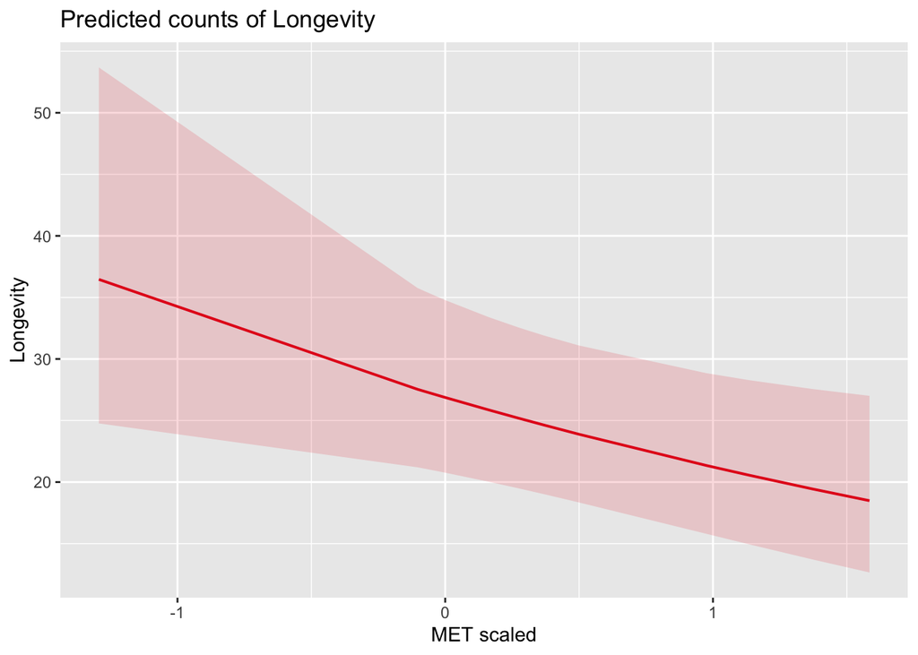

```r
plot_model(ohia.met.nb, type = "pred", terms=c("MET_scaled"))
```

Yes, it looks like it does, but weakly.

*whether historical evapotranspiration at a site predicts the effect of press drought on longevity*

```r
ohia.met.nb.dr = glmer.nb(Longevity ~ MET_scaled *Drought+ (1|Population) + (1|Block), data = ohia_t)
summary(ohia.met.nb.dr)
```

```
## Generalized linear mixed model fit by maximum likelihood (Laplace
##   Approximation) [glmerMod]
##  Family: Negative Binomial(10.8619)  ( log )
## Formula: Longevity ~ MET_scaled * Drought + (1 | Population) + (1 | Block)
##    Data: ohia_t
##
##      AIC      BIC   logLik deviance df.resid
##   1292.1   1313.9   -639.1   1278.1      159
##
## Scaled residuals:
##     Min      1Q  Median      3Q     Max
## -2.0756 -0.6933 -0.0731  0.5654  3.4050
##
## Random effects:
##  Groups     Name        Variance Std.Dev.
##  Population (Intercept) 0.06517  0.2553
##  Block      (Intercept) 0.09779  0.3127
## Number of obs: 166, groups:  Population, 15; Block, 9
##
## Fixed effects:
##                           Estimate Std. Error z value Pr(>|z|)
## (Intercept)                3.28489    0.13545  24.251   <2e-16 ***
## MET_scaled                -0.25101    0.11059  -2.270   0.0232 *
## Droughtdrought             0.02442    0.06015   0.406   0.6847
## MET_scaled:Droughtdrought  0.04636    0.05689   0.815   0.4152
## ---
## Signif. codes:  0 '***' 0.001 '**' 0.01 '*' 0.05 '.' 0.1 ' ' 1
##
## Correlation of Fixed Effects:
##             (Intr) MET_sc Drghtd
## MET_scaled  -0.116
## Droghtdrght -0.146  0.025
## MET_scld:Dr -0.006 -0.189  0.166
```

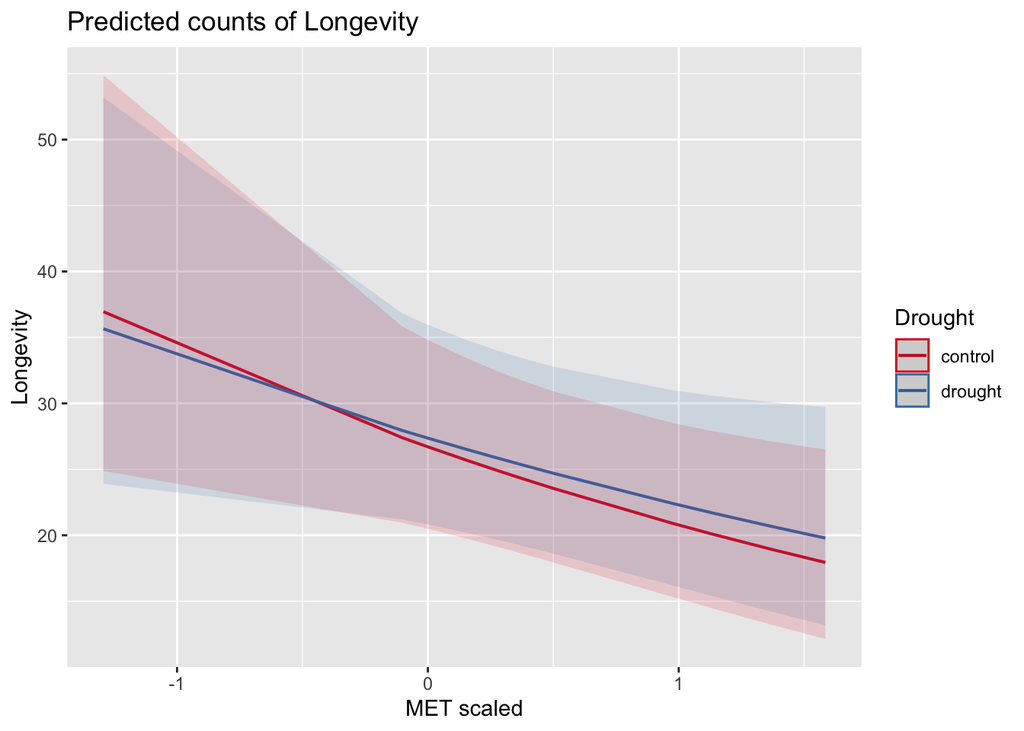

```r
plot_model(ohia.met.nb.dr, type = "pred", terms=c("MET_scaled","Drought"))
```

No. No?

*How do you interpret the results?*

Boy this is a real slog and painful to look at. AND late. Yikes. Someone said this homework was easy because it was a lot of copy and pasting different formulas, and I think I over-thought every single model and didn’t overthink it in a good way.. Ugh. UGH!